# Analiza prognozowanych zmian demograficznych w wybranych krajach Europy w latach 2020-2100

Wojciech Jankowiak, Bartłomiej Michalak

## 1 Wprowadzenie

Zmiany demograrficzne są obecnie jednym z większych problemów współczesnego świata. Zmieniająca się wielkość populacji powoduję w państwach zmiany takie jak ożywienie lub kryzys gospodarczy,polepszenie lub pogorszenie warunków życia, odmładzanie lub starzenie się społeczeństwa, co może prowadzić do zapaści systemów emerytalnych, czy zmiany na rynku pracy. Zmiany liczby ludności zależą od wielu czynników, m.in migracje ludności, ubytek naturalny, dzietność kobiet. Dzięki prognozom zmian demograficznych jesteśmy w stanie, chociażby w najmniejszym stopniu, przygotować się na zmiany lub możliwie jak najbardziej zmienić prognozy na naszą korzyść.

Celem naszej analizy jest opisanie charakterystyki prognoz zmian demograficznych w wybranych europejskich krajach, scharakteryzowanie prognoz dla Polski na tle pozostałych państw oraz prognozy dla całej Europy. Analizę przeprowadzimy na podstawie danych z eurostatu.

## 2 Dane

Podczas przeprowadzania analiz korzystaliśmy z danych pobranych z eurostatu (Europejski Urząd Statystyczny). Z portalu pobraliśmy dane dotyczące prognozowanych zmian demograficznych wybranych państw europejskich. Dane pobraliśmy ze strony ec.europa.eu/eurostat/, z kategorii Population and social conditions.

## 3 Metody analiz

Wszystkie analizy wykonywaliśmy w środowisku R. W trakcie analizowania i wizualizacji danych, oprócz pakietów wbudowanych, użyliśmy również:

- pakiet `eurostat`- pozwala na pobranie danych Eurostatu
- pakiet `dplyr`- zapewnia narzędzia pomagające z uporządkowaniem i wyselekcjonowaniem danych
- pakiet `ggplot2`- umożliwia wizualizację danych
- pakiet `cowplot` - pozwala na dodanie ikon do wykresu
- pakiet `magick` - pozwala na dodanie ikon do wykresu

## 4 Prognozowana zmiana procentowa populacji wybranych pańtw w Europie - analiza dla roku 2060

[figure not shown]

```r
library(eurostat)
library(dplyr)
library(ggplot2)
library(cowplot)
library(magick)

## dane
get_data_gen = function(x) {
  dane = get_eurostat("tps00002", type = "code", filters = list(time = x), time_format = "num")
  dane = filter(dane, geo != "EU27_2020", geo != "EA19", geo != "EL")
  dane = filter(dane, sex == "T")
  dane = dane$values
}

pop_2020 = get_data_gen(2020)
pop_2060 = get_data_gen(2060)
pop_2100 = get_data_gen(2100)

EU_2020 = sum(pop_2020)
EU_2060 = sum(pop_2060)
EU_2100 = sum(pop_2100)

dat2020 = get_eurostat("tps00002", type = "code", filters = list(time = 2020), time_format = "num")
dat2020 = filter(dat2020, geo != "EU27_2020", geo != "EA19", geo != "EL")
dat2020 = filter(dat2020, sex == "T")
kraj_id = dat2020$geo
zmiana20_60 = round(100 - (pop_2020/pop_2060 * 100), 2)
tempo_zmian = data.frame(kraj_id, zmiana20_60)
sort2060 = arrange(tempo_zmian,(zmiana20_60))

## wykres
wykres2060 = ggplot(sort2060, aes(x = reorder(`kraj_id`, zmiana20_60),
                                  y=zmiana20_60, label = zmiana20_60)) +
  geom_point(stat='identity', fill="black", size = 8)  +
  geom_segment(aes(y = 0,
                   x = `kraj_id`,
                   yend = zmiana20_60,
                   xend = `kraj_id`),
                color = "black") +
  geom_text(color = "white", size = 2) +
  labs(y = "Zmiana procentowa", x = "") +
  theme(axis.text.y = element_blank(),
        plot.background = element_rect(fill = "grey90")) +
  coord_flip()

a = 2.90
icons = axis_canvas(wykres2060, axis = "y") +
  draw_image("https://upload.wikimedia.org/wikipedia/commons/thumb/8/84/Flag_of_Latvia.svg/125px-Flag_of_Latvia.svg.png", y = -52.3, scale = 2, width = 0.7, height = 0.7) +
  draw_image("https://upload.wikimedia.org/wikipedia/commons/thumb/1/11/Flag_of_Lithuania.svg/125px-Flag_of_Lithuania.svg.png", y = -49.5, scale = 2, width = 0.7, height = 0.7) +
  draw_image("https://upload.wikimedia.org/wikipedia/commons/thumb/7/73/Flag_of_Romania.svg/125px-Flag_of_Romania.svg.png", y = -52.3 + 2*a, scale = 2, width = 0.7, height = 0.7) +
  draw_image("https://upload.wikimedia.org/wikipedia/commons/thumb/9/9a/Flag_of_Bulgaria.svg/125px-Flag_of_Bulgaria.svg.png", y = -52.3 + 3*a, scale = 2, width = 0.7, height = 0.7) +
  draw_image("https://upload.wikimedia.org/wikipedia/commons/thumb/1/1b/Flag_of_Croatia.svg/125px-Flag_of_Croatia.svg.png", y = -52.3 + 4*a, scale = 2, width = 0.7, height = 0.7) +
  draw_image("https://upload.wikimedia.org/wikipedia/commons/thumb/1/12/Flag_of_Poland.svg/125px-Flag_of_Poland.svg.png", y = -52.3 + 5*a, scale = 2, width = 0.7, height = 0.7) +
  draw_image("https://upload.wikimedia.org/wikipedia/commons/thumb/5/5c/Flag_of_Portugal.svg/125px-Flag_of_Portugal.svg.png", y = -52.3 + 6*a, scale = 2, width = 0.7, height = 0.7) +
  draw_image("https://upload.wikimedia.org/wikipedia/commons/thumb/e/e6/Flag_of_Slovakia.svg/125px-Flag_of_Slovakia.svg.png", y = -52.3 + 7*a, scale = 2, width = 0.7, height = 0.7) +
  draw_image("https://upload.wikimedia.org/wikipedia/commons/thumb/8/8f/Flag_of_Estonia.svg/125px-Flag_of_Estonia.svg.png", y = -52.3 + 8*a, scale = 2, width = 0.7, height = 0.7) +
  draw_image("https://upload.wikimedia.org/wikipedia/commons/thumb/0/03/Flag_of_Italy.svg/125px-Flag_of_Italy.svg.png", y = -52.3 + 9*a, scale = 2, width = 0.7, height = 0.7) +
  draw_image("https://upload.wikimedia.org/wikipedia/commons/thumb/b/bc/Flag_of_Finland.svg/125px-Flag_of_Finland.svg.png", y = -52.3 + 10*a, scale = 2, width = 0.7, height = 0.7) +
  draw_image("https://upload.wikimedia.org/wikipedia/commons/thumb/c/c1/Flag_of_Hungary.svg/125px-Flag_of_Hungary.svg.png", y = -52.3 + 11*a, scale = 2, width = 0.7, height = 0.7) +
  draw_image("https://upload.wikimedia.org/wikipedia/commons/thumb/f/f0/Flag_of_Slovenia.svg/125px-Flag_of_Slovenia.svg.png", y = -52.3 + 12*a, scale = 2, width = 0.7, height = 0.7) +
  draw_image("https://upload.wikimedia.org/wikipedia/commons/thumb/c/cb/Flag_of_the_Czech_Republic.svg/240px-Flag_of_the_Czech_Republic.svg.png", y = -52.3 + 13*a, scale = 2, width = 0.7, height = 0.7) +
  draw_image("https://upload.wikimedia.org/wikipedia/commons/thumb/b/ba/Flag_of_Germany.svg/125px-Flag_of_Germany.svg.png", y = -52.3 + 14*a, scale = 2, width = 0.7, height = 0.7) +
  draw_image("https://upload.wikimedia.org/wikipedia/commons/thumb/9/9a/Flag_of_Spain.svg/125px-Flag_of_Spain.svg.png", y = -52.3 + 15*a, scale = 2, width = 0.7, height = 0.7) +
  draw_image("https://upload.wikimedia.org/wikipedia/commons/thumb/6/65/Flag_of_Belgium.svg/125px-Flag_of_Belgium.svg.png", y = -52.3 + 16*a, scale = 2, width = 0.7, height = 0.85) +
  draw_image("https://upload.wikimedia.org/wikipedia/commons/thumb/2/20/Flag_of_the_Netherlands.svg/125px-Flag_of_the_Netherlands.svg.png", y = -52.3 + 17*a, scale = 2, width = 0.7, height = 0.7) +
  draw_image("https://upload.wikimedia.org/wikipedia/commons/thumb/c/c3/Flag_of_France.svg/125px-Flag_of_France.svg.png", y = -52.3 + 18*a, scale = 2, width = 0.7, height = 0.7) +
  draw_image("https://upload.wikimedia.org/wikipedia/commons/thumb/4/41/Flag_of_Austria.svg/125px-Flag_of_Austria.svg.png", y = -52.3 + 19*a, scale = 2, width = 0.7, height = 0.7) +
  draw_image("https://upload.wikimedia.org/wikipedia/commons/thumb/9/9c/Flag_of_Denmark.svg/125px-Flag_of_Denmark.svg.png", y = -52.3 + 20*a, scale = 2, width = 0.7, height = 0.7) +
  draw_image("https://upload.wikimedia.org/wikipedia/commons/thumb/4/47/Flag_of_Liechtenstein.svg/125px-Flag_of_Liechtenstein.svg.png", y = -52.3 + 21*a, scale = 2, width = 0.7, height = 0.7) +
  draw_image("https://upload.wikimedia.org/wikipedia/commons/thumb/f/f3/Flag_of_Switzerland.svg/125px-Flag_of_Switzerland.svg.png", y = -52.3 + 22*a, scale = 2, width = 0.7, height = 0.7) +
  draw_image("https://upload.wikimedia.org/wikipedia/commons/thumb/d/d4/Flag_of_Cyprus.svg/125px-Flag_of_Cyprus.svg.png", y = -52.3 + 23*a, scale = 2, width = 0.7, height = 0.7) +
  draw_image("https://upload.wikimedia.org/wikipedia/commons/thumb/d/d9/Flag_of_Norway.svg/125px-Flag_of_Norway.svg.png", y = -52.3 + 24*a, scale = 2, width = 0.7, height = 0.7) +
  draw_image("https://upload.wikimedia.org/wikipedia/commons/thumb/4/4c/Flag_of_Sweden.svg/125px-Flag_of_Sweden.svg.png", y = -52.3 + 25*a, scale = 2, width = 0.7, height = 0.7) +
  draw_image("https://upload.wikimedia.org/wikipedia/commons/thumb/d/da/Flag_of_Luxembourg.svg/125px-Flag_of_Luxembourg.svg.png", y = -52.3 + 26*a, scale = 2, width = 0.7, height = 0.7) +
  draw_image("https://upload.wikimedia.org/wikipedia/commons/thumb/4/45/Flag_of_Ireland.svg/125px-Flag_of_Ireland.svg.png", y = -52.3 + 27*a, scale = 2, width = 0.7, height = 0.7) +
  draw_image("https://upload.wikimedia.org/wikipedia/commons/thumb/7/73/Flag_of_Malta.svg/125px-Flag_of_Malta.svg.png", y = -52.3 + 28*a, scale = 2, width = 0.7, height = 0.7) +
  draw_image("https://upload.wikimedia.org/wikipedia/commons/thumb/c/ce/Flag_of_Iceland.svg/125px-Flag_of_Iceland.svg.png", y = -52.3 + 29*a, scale = 2, width = 0.7, height = 0.7)
(wykres2060 = ggdraw(insert_yaxis_grob(wykres2060, icons, position = "left")))
```

*Ryc.1. Prognozowana procentowa zmiana liczby ludności w wybranych państwach Europy w roku 2060*

## 5 Prognozowana zmiana procentowa populacji wybranych państw w Europie - analiza dla roku 2100

[figure not shown]

```r
library(eurostat)
library(dplyr)
library(ggplot2)
library(cowplot)
library(magick)

## dane
get_data_gen = function(x) {
  dane = get_eurostat("tps00002", type = "code", filters = list(time = x), time_format = "num")
  dane = filter(dane, geo != "EU27_2020", geo != "EA19", geo != "EL")
  dane = filter(dane, sex == "T")
  dane = dane$values
}

pop_2020 = get_data_gen(2020)
pop_2030 = get_data_gen(2030)
pop_2040 = get_data_gen(2040)
pop_2050 = get_data_gen(2050)
pop_2060 = get_data_gen(2060)
pop_2070 = get_data_gen(2070)
pop_2080 = get_data_gen(2080)
pop_2090 = get_data_gen(2090)
pop_2100 = get_data_gen(2100)

EU_2020 = sum(pop_2020)
EU_2060 = sum(pop_2060)
EU_2100 = sum(pop_2100)

dat2020 = get_eurostat("tps00002", type = "code", filters = list(time = 2020), time_format = "num")
dat2020 = filter(dat2020, geo != "EU27_2020", geo != "EA19", geo != "EL")
dat2020 = filter(dat2020, sex == "T")
kraj_id = dat2020$geo
zmiana20_100 = round(100 - (pop_2020/pop_2100 * 100), 2)
test = data.frame(kraj_id, zmiana20_100)
sort2100 = arrange(test,(zmiana20_100))

## wykres
wykres2100 = ggplot(sort2100, aes(x = reorder(`kraj_id`, zmiana20_100),
                                  y=zmiana20_100, label=zmiana20_100)) +
  geom_point(stat='identity', fill="black", size = 8)  +
  geom_segment(aes(y = 0,
                   x = `kraj_id`,
                   yend = zmiana20_100,
                   xend = `kraj_id`),
               color = "black") +
  geom_text(color="white", size=2) +
  labs(y = "Zmiana procentowa", x = "") +
  theme(plot.background = element_rect(fill = "grey90",),
        axis.text.y = element_blank(),
        plot.title = element_text(size = 18, hjust = 0.5)) +
  coord_flip()

a = 4.3
icons = axis_canvas(wykres2100, axis = "y") +
  draw_image("https://upload.wikimedia.org/wikipedia/commons/thumb/8/84/Flag_of_Latvia.svg/125px-Flag_of_Latvia.svg.png", y = -80.35, scale = 2, width = 0.7, height = 0.7) +
  draw_image("https://upload.wikimedia.org/wikipedia/commons/thumb/1/11/Flag_of_Lithuania.svg/125px-Flag_of_Lithuania.svg.png", y = -80.35 + a, scale = 2, width = 0.7, height = 0.7) +
  draw_image("https://upload.wikimedia.org/wikipedia/commons/thumb/7/73/Flag_of_Romania.svg/125px-Flag_of_Romania.svg.png", y = -80.35 + 2*a, scale = 2, width = 0.7, height = 0.7) +
  draw_image("https://upload.wikimedia.org/wikipedia/commons/thumb/9/9a/Flag_of_Bulgaria.svg/125px-Flag_of_Bulgaria.svg.png", y = -80.35 + 3*a, scale = 2, width = 0.7, height = 0.7) +
  draw_image("https://upload.wikimedia.org/wikipedia/commons/thumb/1/1b/Flag_of_Croatia.svg/125px-Flag_of_Croatia.svg.png", y = -80.35 + 4*a, scale = 2, width = 0.7, height = 0.7) +
  draw_image("https://upload.wikimedia.org/wikipedia/commons/thumb/1/12/Flag_of_Poland.svg/125px-Flag_of_Poland.svg.png", y = -80.35 + 5*a, scale = 2, width = 0.7, height = 0.7) +
  draw_image("https://upload.wikimedia.org/wikipedia/commons/thumb/5/5c/Flag_of_Portugal.svg/125px-Flag_of_Portugal.svg.png", y = -80.35 + 6*a, scale = 2, width = 0.7, height = 0.7) +
  draw_image("https://upload.wikimedia.org/wikipedia/commons/thumb/e/e6/Flag_of_Slovakia.svg/125px-Flag_of_Slovakia.svg.png", y = -80.35 + 7*a, scale = 2, width = 0.7, height = 0.7) +
  draw_image("https://upload.wikimedia.org/wikipedia/commons/thumb/0/03/Flag_of_Italy.svg/125px-Flag_of_Italy.svg.png", y = -80.35 + 8*a, scale = 2, width = 0.7, height = 0.7) +
  draw_image("https://upload.wikimedia.org/wikipedia/commons/thumb/b/bc/Flag_of_Finland.svg/125px-Flag_of_Finland.svg.png", y = -80.35 + 9*a, scale = 2, width = 0.7, height = 0.7) +
  draw_image("https://upload.wikimedia.org/wikipedia/commons/thumb/8/8f/Flag_of_Estonia.svg/125px-Flag_of_Estonia.svg.png", y = -80.35 + 10*a, scale = 2, width = 0.7, height = 0.7) +
  draw_image("https://upload.wikimedia.org/wikipedia/commons/thumb/c/c1/Flag_of_Hungary.svg/125px-Flag_of_Hungary.svg.png", y = -80.35 + 11*a, scale = 2, width = 0.7, height = 0.7) +
  draw_image("https://upload.wikimedia.org/wikipedia/commons/thumb/f/f0/Flag_of_Slovenia.svg/125px-Flag_of_Slovenia.svg.png", y = -80.35 + 12*a, scale = 2, width = 0.7, height = 0.7) +
  draw_image("https://upload.wikimedia.org/wikipedia/commons/thumb/c/cb/Flag_of_the_Czech_Republic.svg/240px-Flag_of_the_Czech_Republic.svg.png", y = -80.35 + 13*a, scale = 2, width = 0.7, height = 0.7) +
  draw_image("https://upload.wikimedia.org/wikipedia/commons/thumb/9/9a/Flag_of_Spain.svg/125px-Flag_of_Spain.svg.png", y = -80.35 + 14*a, scale = 2, width = 0.7, height = 0.7) +
  draw_image("https://upload.wikimedia.org/wikipedia/commons/thumb/b/ba/Flag_of_Germany.svg/125px-Flag_of_Germany.svg.png", y = -80.35 + 15*a, scale = 2, width = 0.7, height = 0.7) +
  draw_image("https://upload.wikimedia.org/wikipedia/commons/thumb/6/65/Flag_of_Belgium.svg/125px-Flag_of_Belgium.svg.png", y = -80.35 + 16*a, scale = 2, width = 0.7, height = 0.9) +
  draw_image("https://upload.wikimedia.org/wikipedia/commons/thumb/2/20/Flag_of_the_Netherlands.svg/125px-Flag_of_the_Netherlands.svg.png", y = -80.35 + 17*a, scale = 2, width = 0.7, height = 0.7) +
  draw_image("https://upload.wikimedia.org/wikipedia/commons/thumb/c/c3/Flag_of_France.svg/125px-Flag_of_France.svg.png", y = -80.35 + 18*a, scale = 2, width = 0.7, height = 0.7) +
  draw_image("https://upload.wikimedia.org/wikipedia/commons/thumb/4/41/Flag_of_Austria.svg/125px-Flag_of_Austria.svg.png", y = -80.35 + 19*a, scale = 2, width = 0.7, height = 0.7) +
  draw_image("https://upload.wikimedia.org/wikipedia/commons/thumb/9/9c/Flag_of_Denmark.svg/125px-Flag_of_Denmark.svg.png", y = -80.35 + 20*a, scale = 2, width = 0.7, height = 0.7) +
  draw_image("https://upload.wikimedia.org/wikipedia/commons/thumb/d/da/Flag_of_Luxembourg.svg/125px-Flag_of_Luxembourg.svg.png", y = -80.35 + 21*a, scale = 2, width = 0.7, height = 0.7) +
  draw_image("https://upload.wikimedia.org/wikipedia/commons/thumb/d/d4/Flag_of_Cyprus.svg/125px-Flag_of_Cyprus.svg.png", y = -80.35 + 22*a, scale = 2, width = 0.7, height = 0.7) +
  draw_image("https://upload.wikimedia.org/wikipedia/commons/thumb/4/47/Flag_of_Liechtenstein.svg/125px-Flag_of_Liechtenstein.svg.png", y = -80.35 + 23*a, scale = 2, width = 0.7, height = 0.7) +
  draw_image("https://upload.wikimedia.org/wikipedia/commons/thumb/d/d9/Flag_of_Norway.svg/125px-Flag_of_Norway.svg.png", y = -80.35 + 24*a, scale = 2, width = 0.7, height = 0.7) +
  draw_image("https://upload.wikimedia.org/wikipedia/commons/thumb/4/4c/Flag_of_Sweden.svg/125px-Flag_of_Sweden.svg.png", y = -80.35 + 25*a, scale = 2, width = 0.7, height = 0.7) +
  draw_image("https://upload.wikimedia.org/wikipedia/commons/thumb/4/45/Flag_of_Ireland.svg/125px-Flag_of_Ireland.svg.png", y = -80.35 + 26*a, scale = 2, width = 0.7, height = 0.7) +
  draw_image("https://upload.wikimedia.org/wikipedia/commons/thumb/7/73/Flag_of_Malta.svg/125px-Flag_of_Malta.svg.png", y = -80.35 + 27*a, scale = 2, width = 0.7, height = 0.7) +
  draw_image("https://upload.wikimedia.org/wikipedia/commons/thumb/f/f3/Flag_of_Switzerland.svg/125px-Flag_of_Switzerland.svg.png", y = -80.35 + 28*a, scale = 2, width = 0.7, height = 0.9) +
  draw_image("https://upload.wikimedia.org/wikipedia/commons/thumb/c/ce/Flag_of_Iceland.svg/125px-Flag_of_Iceland.svg.png", y = -80.35 + 29*a, scale = 2, width = 0.7, height = 0.7)
(wykres2100 = ggdraw(insert_yaxis_grob(wykres2100, icons, position = "left")))
```

*Ryc.2. Prognozowana procentowa zmiana liczby ludności w wybranych państwach Europy w roku 2100*

## 6 Odchylenie standardowe

Odchylenie standardowe zostało obliczone na podstawie danych procentowej zmiany populacji dla każdego państwa. Aby uzyskać realne dane procentowa zmiana populacji państw obliczana była dla każdego dziesięciolecia w porównaniu do danych sprzed dekady. Pozwoliło to ocenić czy rozrzut wartości dla kolejnych lat rośnie, czy maleje, a co za tym idzie, czy zmiany w ilości ludzi z każdym dziesięcioleciem będą się powiększały, czy może wręcz odwrotnie. Na poniższym wykresie możemy zaobserwować, że odchylenie standardowe z dziesięciolecia na dziesięciolecie spada, co oznacza, że różnice (rozrzut) wartości zmniejszają się względem siebie. Świadczy to o powolnym wyhamowywaniu zmian demograficznych w Europie do 2100 roku. Biorąc pod uwagę wyraźną i systematyczną tendencję spadku możemy przyjąć, że na początku XXIIw. liczba ludności nie będzie się zmieniała tak gwałtownie, jak ma to miejsce w dzisiejszych czasach.

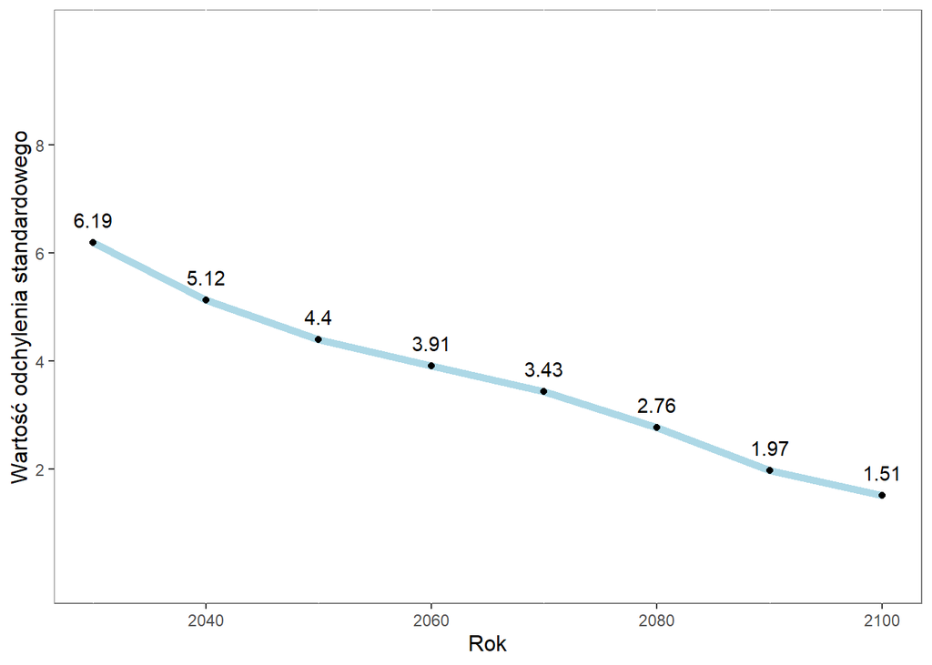

```r
library(eurostat)
library(dplyr)
library(ggplot2)
library(cowplot)
library(magick)

## dane
get_data_gen = function(x) {
  dane = get_eurostat("tps00002", type = "code", filters = list(time = x), time_format = "num")
  dane = filter(dane, geo != "EU27_2020", geo != "EA19", geo != "EL")
  dane = filter(dane, sex == "T")
  dane = dane$values
}

pop_2020 = get_data_gen(2020)
pop_2030 = get_data_gen(2030)
pop_2040 = get_data_gen(2040)
pop_2050 = get_data_gen(2050)
pop_2060 = get_data_gen(2060)
pop_2070 = get_data_gen(2070)
pop_2080 = get_data_gen(2080)
pop_2090 = get_data_gen(2090)
pop_2100 = get_data_gen(2100)

EU_2020 = sum(pop_2020)
EU_2060 = sum(pop_2060)
EU_2100 = sum(pop_2100)

dat2020 = get_eurostat("tps00002", type = "code", filters = list(time = 2020), time_format = "num")
dat2020 = filter(dat2020, geo != "EU27_2020", geo != "EA19", geo != "EL")
dat2020 = filter(dat2020, sex == "T")
kraj_id = dat2020$geo

## odchylenie standardowe procentowego wzrostu/spadku
odchylenie = function(rok_a, rok_b) {
  zmiana = round(100 - (rok_a / rok_b * 100), 2)
  okragl = sd(zmiana)
  odchylenie = round(okragl, 2)
  return(odchylenie)
}
od_st_2030 = odchylenie(pop_2020, pop_2030)
od_st_2040 = odchylenie(pop_2030, pop_2040)
od_st_2050 = odchylenie(pop_2040, pop_2050)
od_st_2060 = odchylenie(pop_2050, pop_2060)
od_st_2070 = odchylenie(pop_2060, pop_2070)
od_st_2080 = odchylenie(pop_2070, pop_2080)
od_st_2090 = odchylenie(pop_2080, pop_2090)
od_st_2100 = odchylenie(pop_2090, pop_2100)

## wykres
odchylenie_ramka = data.frame(Rok = c(2030, 2040, 2050, 2060, 2070, 2080, 2090, 2100),
                              od_dla_lat = c(od_st_2030, od_st_2040, od_st_2050, od_st_2060,
                                             od_st_2070, od_st_2080, od_st_2090, od_st_2100))

ggplot(odchylenie_ramka, aes(x = Rok, y = od_dla_lat)) +
  geom_line(stat = "identity", colour = "lightblue", size = 2) +
  scale_y_continuous(limits = c(0, 10),
                     breaks = c(2, 4, 6, 8)) +
  labs(y = "Wartość odchylenia standardowego") +
  theme(panel.background = element_rect(fill = "white", colour = "grey50"),
        panel.grid.major.y = element_blank(),
        panel.grid.minor.y = element_blank(),
        axis.title = element_text(size = 12),
        plot.title = element_text(size = 18, hjust = 0.5)) +
  geom_point(aes(x = Rok, y = od_dla_lat)) +
  geom_text(aes(label = od_dla_lat), hjust = 0.5, vjust = -1)
```

*Ryc.3. Odchylenie standardowe* *Obliczone z procentowych prognoz zmian populacji dla każdej dekady w porównaniu do danych z poprzedniej*

## 7 Prognozy zmian demograficznych dla Polski

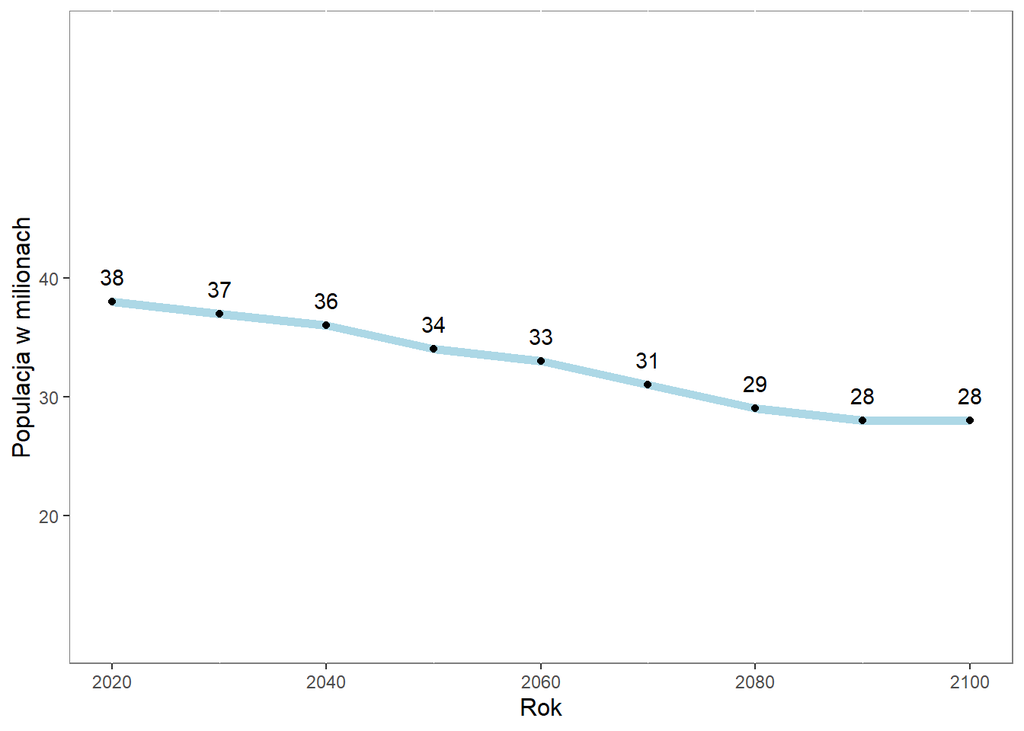

```r
library(eurostat)
library(dplyr)
library(ggplot2)

## dane
get_data_for_pol = function(x) {
  dane = get_eurostat("tps00002", type = "code", filters = list(time = x), time_format = "num")
  dane = filter(dane, geo != "EU27_2020", geo != "EA19", geo != "EL")
  dane = filter(dane, geo == "PL")
  dane = filter(dane, sex == "T")
  dane = pull(dane, values)
  dane = round(dane / 1000000)
}

Ludnosc_2020_Pol = get_data_for_pol(2020)
Ludnosc_2030_Pol = get_data_for_pol(2030)
Ludnosc_2040_Pol = get_data_for_pol(2040)
Ludnosc_2050_Pol = get_data_for_pol(2050)
Ludnosc_2060_Pol = get_data_for_pol(2060)
Ludnosc_2070_Pol = get_data_for_pol(2070)
Ludnosc_2080_Pol = get_data_for_pol(2080)
Ludnosc_2090_Pol = get_data_for_pol(2090)
Ludnosc_2100_Pol = get_data_for_pol(2100)

Dane_Polski = data.frame(Rok = c(2020, 2030, 2040, 2050, 2060, 2070, 2080, 2090, 2100),
                         Populacja = c(Ludnosc_2020_Pol, Ludnosc_2030_Pol, Ludnosc_2040_Pol, Ludnosc_2050_Pol, Ludnosc_2060_Pol, Ludnosc_2070_Pol, Ludnosc_2080_Pol, Ludnosc_2090_Pol, Ludnosc_2100_Pol))

## wykres
ggplot(Dane_Polski, aes(x = Rok, y = Populacja)) +
  geom_line(stat = "identity", colour = "lightblue", size = 2) +
  scale_y_continuous(limits = c(10, 60),
                     breaks = c(20, 30, 40)) +
  labs(y = "Populacja w milionach") +
  theme(panel.background = element_rect(fill = "white", colour = "grey50"),
        panel.grid.major.y = element_blank(),
        panel.grid.minor.y = element_blank(),
        axis.title = element_text(size = 12),
        plot.title = element_text(size = 18, hjust = 0.5)) +
  geom_point(aes(x = Rok, y = Populacja)) +
  geom_text(aes(label = Populacja), hjust = 0.5, vjust = -1)
```

*Ryc.4. Zmiany demograficzne w Polsce w latach 2020-2100*